# Optimal Treatment Analysis

## Outcome Variable

**Outcome Variable:** ever_stunted

## Predictor Variables

**Intervention Variable:** predexfd6

**Adjustment Set:**

- arm
- sex
- W_mage
- meducyrs
- feducyrs
- hhwealth_quart
- hfoodsec
- W_mhtcm
- vagbrth
- W_gagebrth
- W_birthwt
- W_birthlen
- W_nrooms
- W_nchldlt5
- month
- brthmon
- W_parity
- impfloor
- impsan
- safeh20
- delta_W_mage
- delta_meducyrs
- delta_feducyrs
- delta_hhwealth_quart
- delta_hfoodsec
- delta_W_mhtcm
- delta_vagbrth
- delta_W_gagebrth
- delta_W_birthwt
- delta_W_birthlen
- delta_W_nrooms
- delta_W_nchldlt5
- delta_month
- delta_brthmon
- delta_W_parity
- delta_impfloor
- delta_impsan
- delta_safeh20

## Stratifying Variables

The analysis was stratified on these variable(s):

- agecat
- studyid
- country

## Data Summary

| agecat | studyid | country | predexfd6 | ever_stunted | n_cell | n |
| --- | --- | --- | --- | --- | --- | --- |
| 0-24 months (no birth st.) | ki0047075b-MAL-ED | BANGLADESH | 1 | 0 | 45 | 198 |
| 0-24 months (no birth st.) | ki0047075b-MAL-ED | BANGLADESH | 1 | 1 | 61 | 198 |
| 0-24 months (no birth st.) | ki0047075b-MAL-ED | BANGLADESH | 0 | 0 | 46 | 198 |
| 0-24 months (no birth st.) | ki0047075b-MAL-ED | BANGLADESH | 0 | 1 | 46 | 198 |
| 0-24 months (no birth st.) | ki0047075b-MAL-ED | BRAZIL | 1 | 0 | 28 | 191 |
| 0-24 months (no birth st.) | ki0047075b-MAL-ED | BRAZIL | 1 | 1 | 4 | 191 |
| 0-24 months (no birth st.) | ki0047075b-MAL-ED | BRAZIL | 0 | 0 | 135 | 191 |
| 0-24 months (no birth st.) | ki0047075b-MAL-ED | BRAZIL | 0 | 1 | 24 | 191 |
| 0-24 months (no birth st.) | ki0047075b-MAL-ED | INDIA | 1 | 0 | 4 | 194 |
| 0-24 months (no birth st.) | ki0047075b-MAL-ED | INDIA | 1 | 1 | 9 | 194 |
| 0-24 months (no birth st.) | ki0047075b-MAL-ED | INDIA | 0 | 0 | 84 | 194 |
| 0-24 months (no birth st.) | ki0047075b-MAL-ED | INDIA | 0 | 1 | 97 | 194 |
| 0-24 months (no birth st.) | ki0047075b-MAL-ED | NEPAL | 1 | 0 | 18 | 208 |
| 0-24 months (no birth st.) | ki0047075b-MAL-ED | NEPAL | 1 | 1 | 9 | 208 |
| 0-24 months (no birth st.) | ki0047075b-MAL-ED | NEPAL | 0 | 0 | 136 | 208 |
| 0-24 months (no birth st.) | ki0047075b-MAL-ED | NEPAL | 0 | 1 | 45 | 208 |
| 0-24 months (no birth st.) | ki0047075b-MAL-ED | PERU | 1 | 0 | 45 | 238 |
| 0-24 months (no birth st.) | ki0047075b-MAL-ED | PERU | 1 | 1 | 58 | 238 |
| 0-24 months (no birth st.) | ki0047075b-MAL-ED | PERU | 0 | 0 | 47 | 238 |
| 0-24 months (no birth st.) | ki0047075b-MAL-ED | PERU | 0 | 1 | 88 | 238 |
| 0-24 months (no birth st.) | ki0047075b-MAL-ED | SOUTH AFRICA | 1 | 0 | 0 | 222 |
| 0-24 months (no birth st.) | ki0047075b-MAL-ED | SOUTH AFRICA | 1 | 1 | 1 | 222 |
| 0-24 months (no birth st.) | ki0047075b-MAL-ED | SOUTH AFRICA | 0 | 0 | 96 | 222 |
| 0-24 months (no birth st.) | ki0047075b-MAL-ED | SOUTH AFRICA | 0 | 1 | 125 | 222 |
| 0-24 months (no birth st.) | ki0047075b-MAL-ED | TANZANIA, UNITED REPUBLIC OF | 1 | 0 | 0 | 210 |
| 0-24 months (no birth st.) | ki0047075b-MAL-ED | TANZANIA, UNITED REPUBLIC OF | 1 | 1 | 2 | 210 |
| 0-24 months (no birth st.) | ki0047075b-MAL-ED | TANZANIA, UNITED REPUBLIC OF | 0 | 0 | 35 | 210 |
| 0-24 months (no birth st.) | ki0047075b-MAL-ED | TANZANIA, UNITED REPUBLIC OF | 0 | 1 | 173 | 210 |
| 0-24 months (no birth st.) | ki1000108-CMC-V-BCS-2002 | INDIA | 1 | 0 | 1 | 14 |
| 0-24 months (no birth st.) | ki1000108-CMC-V-BCS-2002 | INDIA | 1 | 1 | 13 | 14 |

[output cut: 186 more lines]

The following strata were considered:

- agecat: 0-24 months (no birth st.), studyid: ki0047075b-MAL-ED, country: BANGLADESH
- agecat: 0-24 months (no birth st.), studyid: ki0047075b-MAL-ED, country: BRAZIL
- agecat: 0-24 months (no birth st.), studyid: ki0047075b-MAL-ED, country: INDIA
- agecat: 0-24 months (no birth st.), studyid: ki0047075b-MAL-ED, country: NEPAL
- agecat: 0-24 months (no birth st.), studyid: ki0047075b-MAL-ED, country: PERU
- agecat: 0-24 months (no birth st.), studyid: ki0047075b-MAL-ED, country: SOUTH AFRICA
- agecat: 0-24 months (no birth st.), studyid: ki0047075b-MAL-ED, country: TANZANIA, UNITED REPUBLIC OF
- agecat: 0-24 months (no birth st.), studyid: ki1000108-CMC-V-BCS-2002, country: INDIA
- agecat: 0-24 months (no birth st.), studyid: ki1000108-IRC, country: INDIA
- agecat: 0-24 months (no birth st.), studyid: ki1000109-EE, country: PAKISTAN
- agecat: 0-24 months (no birth st.), studyid: ki1000304b-SAS-CompFeed, country: INDIA
- agecat: 0-24 months (no birth st.), studyid: ki1000304b-SAS-FoodSuppl, country: INDIA
- agecat: 0-24 months (no birth st.), studyid: ki1017093b-PROVIDE, country: BANGLADESH
- agecat: 0-24 months (no birth st.), studyid: ki1101329-Keneba, country: GAMBIA
- agecat: 0-24 months (no birth st.), studyid: ki1113344-GMS-Nepal, country: NEPAL
- agecat: 0-24 months (no birth st.), studyid: ki1148112-LCNI-5, country: MALAWI
- agecat: 0-24 months (no birth st.), studyid: kiGH5241-JiVitA-3, country: BANGLADESH
- agecat: 0-24 months (no birth st.), studyid: kiGH5241-JiVitA-4, country: BANGLADESH
- agecat: 0-6 months (no birth st.), studyid: ki0047075b-MAL-ED, country: BANGLADESH
- agecat: 0-6 months (no birth st.), studyid: ki0047075b-MAL-ED, country: BRAZIL
- agecat: 0-6 months (no birth st.), studyid: ki0047075b-MAL-ED, country: INDIA
- agecat: 0-6 months (no birth st.), studyid: ki0047075b-MAL-ED, country: NEPAL
- agecat: 0-6 months (no birth st.), studyid: ki0047075b-MAL-ED, country: PERU
- agecat: 0-6 months (no birth st.), studyid: ki0047075b-MAL-ED, country: SOUTH AFRICA
- agecat: 0-6 months (no birth st.), studyid: ki0047075b-MAL-ED, country: TANZANIA, UNITED REPUBLIC OF
- agecat: 0-6 months (no birth st.), studyid: ki1000108-CMC-V-BCS-2002, country: INDIA
- agecat: 0-6 months (no birth st.), studyid: ki1000108-IRC, country: INDIA
- agecat: 0-6 months (no birth st.), studyid: ki1000109-EE, country: PAKISTAN
- agecat: 0-6 months (no birth st.), studyid: ki1000304b-SAS-CompFeed, country: INDIA
- agecat: 0-6 months (no birth st.), studyid: ki1000304b-SAS-FoodSuppl, country: INDIA
- agecat: 0-6 months (no birth st.), studyid: ki1017093b-PROVIDE, country: BANGLADESH
- agecat: 0-6 months (no birth st.), studyid: ki1101329-Keneba, country: GAMBIA
- agecat: 0-6 months (no birth st.), studyid: ki1113344-GMS-Nepal, country: NEPAL
- agecat: 0-6 months (no birth st.), studyid: ki1148112-LCNI-5, country: MALAWI
- agecat: 0-6 months (no birth st.), studyid: kiGH5241-JiVitA-3, country: BANGLADESH
- agecat: 0-6 months (no birth st.), studyid: kiGH5241-JiVitA-4, country: BANGLADESH
- agecat: 6-24 months, studyid: ki0047075b-MAL-ED, country: BANGLADESH
- agecat: 6-24 months, studyid: ki0047075b-MAL-ED, country: BRAZIL
- agecat: 6-24 months, studyid: ki0047075b-MAL-ED, country: INDIA
- agecat: 6-24 months, studyid: ki0047075b-MAL-ED, country: NEPAL
- agecat: 6-24 months, studyid: ki0047075b-MAL-ED, country: PERU
- agecat: 6-24 months, studyid: ki0047075b-MAL-ED, country: SOUTH AFRICA
- agecat: 6-24 months, studyid: ki0047075b-MAL-ED, country: TANZANIA, UNITED REPUBLIC OF
- agecat: 6-24 months, studyid: ki1000108-CMC-V-BCS-2002, country: INDIA
- agecat: 6-24 months, studyid: ki1000108-IRC, country: INDIA
- agecat: 6-24 months, studyid: ki1000109-EE, country: PAKISTAN
- agecat: 6-24 months, studyid: ki1000304b-SAS-CompFeed, country: INDIA
- agecat: 6-24 months, studyid: ki1000304b-SAS-FoodSuppl, country: INDIA
- agecat: 6-24 months, studyid: ki1017093b-PROVIDE, country: BANGLADESH
- agecat: 6-24 months, studyid: ki1101329-Keneba, country: GAMBIA
- agecat: 6-24 months, studyid: ki1113344-GMS-Nepal, country: NEPAL
- agecat: 6-24 months, studyid: ki1148112-LCNI-5, country: MALAWI
- agecat: 6-24 months, studyid: kiGH5241-JiVitA-3, country: BANGLADESH
- agecat: 6-24 months, studyid: kiGH5241-JiVitA-4, country: BANGLADESH

### Dropped Strata

Some strata were dropped due to rare outcomes:

- agecat: 0-24 months (no birth st.), studyid: ki0047075b-MAL-ED, country: BRAZIL
- agecat: 0-24 months (no birth st.), studyid: ki0047075b-MAL-ED, country: INDIA
- agecat: 0-24 months (no birth st.), studyid: ki0047075b-MAL-ED, country: SOUTH AFRICA
- agecat: 0-24 months (no birth st.), studyid: ki0047075b-MAL-ED, country: TANZANIA, UNITED REPUBLIC OF
- agecat: 0-24 months (no birth st.), studyid: ki1000108-CMC-V-BCS-2002, country: INDIA
- agecat: 0-24 months (no birth st.), studyid: ki1000108-IRC, country: INDIA
- agecat: 0-24 months (no birth st.), studyid: ki1000304b-SAS-FoodSuppl, country: INDIA
- agecat: 0-6 months (no birth st.), studyid: ki0047075b-MAL-ED, country: BRAZIL
- agecat: 0-6 months (no birth st.), studyid: ki0047075b-MAL-ED, country: INDIA
- agecat: 0-6 months (no birth st.), studyid: ki0047075b-MAL-ED, country: NEPAL
- agecat: 0-6 months (no birth st.), studyid: ki0047075b-MAL-ED, country: SOUTH AFRICA
- agecat: 0-6 months (no birth st.), studyid: ki0047075b-MAL-ED, country: TANZANIA, UNITED REPUBLIC OF
- agecat: 0-6 months (no birth st.), studyid: ki1000108-CMC-V-BCS-2002, country: INDIA
- agecat: 0-6 months (no birth st.), studyid: ki1000108-IRC, country: INDIA
- agecat: 0-6 months (no birth st.), studyid: ki1000304b-SAS-FoodSuppl, country: INDIA
- agecat: 0-6 months (no birth st.), studyid: ki1148112-LCNI-5, country: MALAWI
- agecat: 6-24 months, studyid: ki0047075b-MAL-ED, country: BRAZIL
- agecat: 6-24 months, studyid: ki0047075b-MAL-ED, country: INDIA
- agecat: 6-24 months, studyid: ki0047075b-MAL-ED, country: SOUTH AFRICA
- agecat: 6-24 months, studyid: ki0047075b-MAL-ED, country: TANZANIA, UNITED REPUBLIC OF
- agecat: 6-24 months, studyid: ki1000108-CMC-V-BCS-2002, country: INDIA
- agecat: 6-24 months, studyid: ki1000108-IRC, country: INDIA
- agecat: 6-24 months, studyid: ki1000304b-SAS-CompFeed, country: INDIA
- agecat: 6-24 months, studyid: ki1000304b-SAS-FoodSuppl, country: INDIA

## Methods Detail

We’re interested in the causal parameters $E[Y_a]$ for all values of $a \in \mathcal{A}$. These parameters represent the mean outcome if, possibly contrary to fact, we intervened to set all units to have $A=a$. Under the randomization and positivity assumptions, these are identified by the statistical parameters $\psi_a=E_W[E_{Y|A,W}(Y|A=a,W)]$. In addition, we’re interested in the mean of $Y$, $E[Y]$ under no intervention (the observed mean). We will estimate these parameters by using SuperLearner to fit the relevant likelihood factors – $E_{Y|A,W}(Y|A=a,W)$ and $p(A=a|W)$, and then updating our likelihood fit using a joint TMLE.

For unadjusted analyses ($W=\{\}$), initial likelihoods were estimated using Lrnr_glm to estimate the simple $E(Y|A)$ and Lrnr_mean to estimate $p(A)$. For adjusted analyses, a small library containing Lrnr_glmnet, Lrnr_xgboost, and Lrnr_mean was used.

Having estimated these parameters, we will then use the delta method to estimate relative risks and attributable risks relative to a prespecified baseline level of $A$.

# Results Detail

## Results Plots

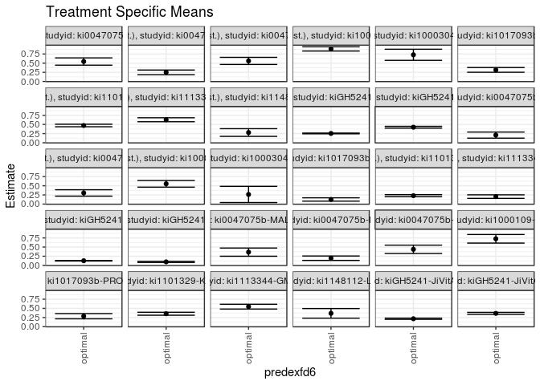

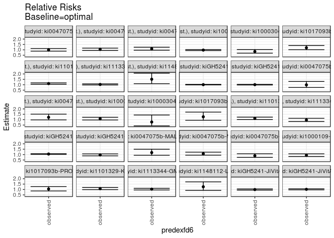

## Results Table

### Parameter: TSM

| agecat | studyid | country | intervention_level | baseline_level | estimate | ci_lower | ci_upper |
| --- | --- | --- | --- | --- | --- | --- | --- |
| 0-24 months (no birth st.) | ki0047075b-MAL-ED | BANGLADESH | optimal | NA | 0.5449079 | 0.4455521 | 0.6442637 |
| 0-24 months (no birth st.) | ki0047075b-MAL-ED | NEPAL | optimal | NA | 0.2485388 | 0.1853545 | 0.3117231 |
| 0-24 months (no birth st.) | ki0047075b-MAL-ED | PERU | optimal | NA | 0.5612142 | 0.4643434 | 0.6580850 |
| 0-24 months (no birth st.) | ki1000109-EE | PAKISTAN | optimal | NA | 0.8887284 | 0.8315635 | 0.9458933 |
| 0-24 months (no birth st.) | ki1000304b-SAS-CompFeed | INDIA | optimal | NA | 0.7282170 | 0.5763313 | 0.8801027 |
| 0-24 months (no birth st.) | ki1017093b-PROVIDE | BANGLADESH | optimal | NA | 0.3154504 | 0.2507614 | 0.3801395 |
| 0-24 months (no birth st.) | ki1101329-Keneba | GAMBIA | optimal | NA | 0.4717609 | 0.4371593 | 0.5063625 |
| 0-24 months (no birth st.) | ki1113344-GMS-Nepal | NEPAL | optimal | NA | 0.6286443 | 0.5748925 | 0.6823961 |
| 0-24 months (no birth st.) | ki1148112-LCNI-5 | MALAWI | optimal | NA | 0.2799221 | 0.1753469 | 0.3844973 |
| 0-24 months (no birth st.) | kiGH5241-JiVitA-3 | BANGLADESH | optimal | NA | 0.2548686 | 0.2450661 | 0.2646712 |
| 0-24 months (no birth st.) | kiGH5241-JiVitA-4 | BANGLADESH | optimal | NA | 0.4244277 | 0.4001973 | 0.4486581 |
| 0-6 months (no birth st.) | ki0047075b-MAL-ED | BANGLADESH | optimal | NA | 0.2097127 | 0.1266304 | 0.2927949 |
| 0-6 months (no birth st.) | ki0047075b-MAL-ED | PERU | optimal | NA | 0.3037868 | 0.2167390 | 0.3908345 |
| 0-6 months (no birth st.) | ki1000109-EE | PAKISTAN | optimal | NA | 0.5530101 | 0.4624607 | 0.6435595 |
| 0-6 months (no birth st.) | ki1000304b-SAS-CompFeed | INDIA | optimal | NA | 0.2630258 | 0.0415842 | 0.4844674 |
| 0-6 months (no birth st.) | ki1017093b-PROVIDE | BANGLADESH | optimal | NA | 0.1257062 | 0.0802659 | 0.1711466 |
| 0-6 months (no birth st.) | ki1101329-Keneba | GAMBIA | optimal | NA | 0.2291505 | 0.2005566 | 0.2577445 |
| 0-6 months (no birth st.) | ki1113344-GMS-Nepal | NEPAL | optimal | NA | 0.2040801 | 0.1559069 | 0.2522533 |
| 0-6 months (no birth st.) | kiGH5241-JiVitA-3 | BANGLADESH | optimal | NA | 0.1266468 | 0.1197445 | 0.1335492 |
| 0-6 months (no birth st.) | kiGH5241-JiVitA-4 | BANGLADESH | optimal | NA | 0.0959523 | 0.0804986 | 0.1114059 |
| 6-24 months | ki0047075b-MAL-ED | BANGLADESH | optimal | NA | 0.3617944 | 0.2497737 | 0.4738152 |
| 6-24 months | ki0047075b-MAL-ED | NEPAL | optimal | NA | 0.1962061 | 0.1359016 | 0.2565106 |
| 6-24 months | ki0047075b-MAL-ED | PERU | optimal | NA | 0.4389232 | 0.3252530 | 0.5525933 |
| 6-24 months | ki1000109-EE | PAKISTAN | optimal | NA | 0.7258777 | 0.6087810 | 0.8429745 |
| 6-24 months | ki1017093b-PROVIDE | BANGLADESH | optimal | NA | 0.2857073 | 0.2143371 | 0.3570774 |
| 6-24 months | ki1101329-Keneba | GAMBIA | optimal | NA | 0.3538550 | 0.3132175 | 0.3944926 |
| 6-24 months | ki1113344-GMS-Nepal | NEPAL | optimal | NA | 0.5468259 | 0.4814848 | 0.6121670 |
| 6-24 months | ki1148112-LCNI-5 | MALAWI | optimal | NA | 0.3640374 | 0.2324512 | 0.4956237 |
| 6-24 months | kiGH5241-JiVitA-3 | BANGLADESH | optimal | NA | 0.2170280 | 0.2011028 | 0.2329532 |
| 6-24 months | kiGH5241-JiVitA-4 | BANGLADESH | optimal | NA | 0.3636459 | 0.3359220 | 0.3913698 |

### Parameter: E(Y)

| agecat | studyid | country | intervention_level | baseline_level | estimate | ci_lower | ci_upper |
| --- | --- | --- | --- | --- | --- | --- | --- |
| 0-24 months (no birth st.) | ki0047075b-MAL-ED | BANGLADESH | observed | NA | 0.5404040 | 0.4708116 | 0.6099965 |
| 0-24 months (no birth st.) | ki0047075b-MAL-ED | NEPAL | observed | NA | 0.2596154 | 0.1998903 | 0.3193405 |
| 0-24 months (no birth st.) | ki0047075b-MAL-ED | PERU | observed | NA | 0.6134454 | 0.5514489 | 0.6754419 |
| 0-24 months (no birth st.) | ki1000109-EE | PAKISTAN | observed | NA | 0.8674699 | 0.8252704 | 0.9096693 |
| 0-24 months (no birth st.) | ki1000304b-SAS-CompFeed | INDIA | observed | NA | 0.6134969 | 0.5286303 | 0.6983635 |
| 0-24 months (no birth st.) | ki1017093b-PROVIDE | BANGLADESH | observed | NA | 0.3753943 | 0.3376725 | 0.4131162 |
| 0-24 months (no birth st.) | ki1101329-Keneba | GAMBIA | observed | NA | 0.5219970 | 0.5002246 | 0.5437695 |
| 0-24 months (no birth st.) | ki1113344-GMS-Nepal | NEPAL | observed | NA | 0.6447106 | 0.6027601 | 0.6866610 |
| 0-24 months (no birth st.) | ki1148112-LCNI-5 | MALAWI | observed | NA | 0.4228571 | 0.3494545 | 0.4962598 |
| 0-24 months (no birth st.) | kiGH5241-JiVitA-3 | BANGLADESH | observed | NA | 0.2568529 | 0.2489241 | 0.2647817 |
| 0-24 months (no birth st.) | kiGH5241-JiVitA-4 | BANGLADESH | observed | NA | 0.4273377 | 0.4072583 | 0.4474171 |
| 0-6 months (no birth st.) | ki0047075b-MAL-ED | BANGLADESH | observed | NA | 0.2070707 | 0.1504870 | 0.2636544 |
| 0-6 months (no birth st.) | ki0047075b-MAL-ED | PERU | observed | NA | 0.3697479 | 0.3082891 | 0.4312067 |
| 0-6 months (no birth st.) | ki1000109-EE | PAKISTAN | observed | NA | 0.6024096 | 0.5415000 | 0.6633193 |
| 0-6 months (no birth st.) | ki1000304b-SAS-CompFeed | INDIA | observed | NA | 0.2055215 | 0.1385538 | 0.2724891 |
| 0-6 months (no birth st.) | ki1017093b-PROVIDE | BANGLADESH | observed | NA | 0.1593060 | 0.1307970 | 0.1878149 |
| 0-6 months (no birth st.) | ki1101329-Keneba | GAMBIA | observed | NA | 0.2560554 | 0.2370317 | 0.2750791 |
| 0-6 months (no birth st.) | ki1113344-GMS-Nepal | NEPAL | observed | NA | 0.1976048 | 0.1627023 | 0.2325072 |
| 0-6 months (no birth st.) | kiGH5241-JiVitA-3 | BANGLADESH | observed | NA | 0.1331973 | 0.1275046 | 0.1388899 |
| 0-6 months (no birth st.) | kiGH5241-JiVitA-4 | BANGLADESH | observed | NA | 0.0929124 | 0.0809295 | 0.1048954 |
| 6-24 months | ki0047075b-MAL-ED | BANGLADESH | observed | NA | 0.4285714 | 0.3501572 | 0.5069857 |
| 6-24 months | ki0047075b-MAL-ED | NEPAL | observed | NA | 0.2113402 | 0.1537425 | 0.2689379 |
| 6-24 months | ki0047075b-MAL-ED | PERU | observed | NA | 0.3918919 | 0.3129763 | 0.4708075 |
| 6-24 months | ki1000109-EE | PAKISTAN | observed | NA | 0.6804124 | 0.5871313 | 0.7736934 |
| 6-24 months | ki1017093b-PROVIDE | BANGLADESH | observed | NA | 0.2997812 | 0.2577294 | 0.3418330 |
| 6-24 months | ki1101329-Keneba | GAMBIA | observed | NA | 0.3823738 | 0.3569722 | 0.4077755 |
| 6-24 months | ki1113344-GMS-Nepal | NEPAL | observed | NA | 0.5642317 | 0.5153938 | 0.6130696 |
| 6-24 months | ki1148112-LCNI-5 | MALAWI | observed | NA | 0.4567901 | 0.3798457 | 0.5337346 |
| 6-24 months | kiGH5241-JiVitA-3 | BANGLADESH | observed | NA | 0.2160008 | 0.2065441 | 0.2254575 |
| 6-24 months | kiGH5241-JiVitA-4 | BANGLADESH | observed | NA | 0.3699441 | 0.3495174 | 0.3903708 |

### Parameter: RR

| agecat | studyid | country | intervention_level | baseline_level | estimate | ci_lower | ci_upper |
| --- | --- | --- | --- | --- | --- | --- | --- |
| 0-24 months (no birth st.) | ki0047075b-MAL-ED | BANGLADESH | observed | optimal | 0.9917346 | 0.8761337 | 1.122588 |
| 0-24 months (no birth st.) | ki0047075b-MAL-ED | NEPAL | observed | optimal | 1.0445670 | 0.9451331 | 1.154462 |
| 0-24 months (no birth st.) | ki0047075b-MAL-ED | PERU | observed | optimal | 1.0930681 | 0.9635805 | 1.239957 |
| 0-24 months (no birth st.) | ki1000109-EE | PAKISTAN | observed | optimal | 0.9760799 | 0.9280845 | 1.026557 |
| 0-24 months (no birth st.) | ki1000304b-SAS-CompFeed | INDIA | observed | optimal | 0.8424645 | 0.6901254 | 1.028431 |
| 0-24 months (no birth st.) | ki1017093b-PROVIDE | BANGLADESH | observed | optimal | 1.1900263 | 1.0078567 | 1.405123 |
| 0-24 months (no birth st.) | ki1101329-Keneba | GAMBIA | observed | optimal | 1.1064864 | 1.0451382 | 1.171436 |
| 0-24 months (no birth st.) | ki1113344-GMS-Nepal | NEPAL | observed | optimal | 1.0255570 | 0.9752135 | 1.078499 |
| 0-24 months (no birth st.) | ki1148112-LCNI-5 | MALAWI | observed | optimal | 1.5106245 | 1.0995318 | 2.075416 |
| 0-24 months (no birth st.) | kiGH5241-JiVitA-3 | BANGLADESH | observed | optimal | 1.0077855 | 0.9838274 | 1.032327 |
| 0-24 months (no birth st.) | kiGH5241-JiVitA-4 | BANGLADESH | observed | optimal | 1.0068562 | 0.9768473 | 1.037787 |
| 0-6 months (no birth st.) | ki0047075b-MAL-ED | BANGLADESH | observed | optimal | 0.9874020 | 0.7481038 | 1.303245 |
| 0-6 months (no birth st.) | ki0047075b-MAL-ED | PERU | observed | optimal | 1.2171297 | 0.9805671 | 1.510763 |
| 0-6 months (no birth st.) | ki1000109-EE | PAKISTAN | observed | optimal | 1.0893285 | 0.9713472 | 1.221640 |
| 0-6 months (no birth st.) | ki1000304b-SAS-CompFeed | INDIA | observed | optimal | 0.7813737 | 0.4262552 | 1.432346 |
| 0-6 months (no birth st.) | ki1017093b-PROVIDE | BANGLADESH | observed | optimal | 1.2672879 | 0.9436727 | 1.701881 |
| 0-6 months (no birth st.) | ki1101329-Keneba | GAMBIA | observed | optimal | 1.1174113 | 1.0127067 | 1.232941 |
| 0-6 months (no birth st.) | ki1113344-GMS-Nepal | NEPAL | observed | optimal | 0.9682706 | 0.8314719 | 1.127576 |
| 0-6 months (no birth st.) | kiGH5241-JiVitA-3 | BANGLADESH | observed | optimal | 1.0517223 | 1.0161023 | 1.088591 |
| 0-6 months (no birth st.) | kiGH5241-JiVitA-4 | BANGLADESH | observed | optimal | 0.9683195 | 0.8804449 | 1.064965 |
| 6-24 months | ki0047075b-MAL-ED | BANGLADESH | observed | optimal | 1.1845716 | 0.9362889 | 1.498693 |
| 6-24 months | ki0047075b-MAL-ED | NEPAL | observed | optimal | 1.0771336 | 0.9451374 | 1.227564 |
| 6-24 months | ki0047075b-MAL-ED | PERU | observed | optimal | 0.8928485 | 0.7409963 | 1.075820 |
| 6-24 months | ki1000109-EE | PAKISTAN | observed | optimal | 0.9373650 | 0.8233725 | 1.067139 |
| 6-24 months | ki1017093b-PROVIDE | BANGLADESH | observed | optimal | 1.0492599 | 0.8675096 | 1.269088 |
| 6-24 months | ki1101329-Keneba | GAMBIA | observed | optimal | 1.0805946 | 0.9859708 | 1.184300 |
| 6-24 months | ki1113344-GMS-Nepal | NEPAL | observed | optimal | 1.0318306 | 0.9563569 | 1.113260 |
| 6-24 months | ki1148112-LCNI-5 | MALAWI | observed | optimal | 1.2547888 | 0.9206507 | 1.710198 |
| 6-24 months | kiGH5241-JiVitA-3 | BANGLADESH | observed | optimal | 0.9952668 | 0.9417861 | 1.051785 |
| 6-24 months | kiGH5241-JiVitA-4 | BANGLADESH | observed | optimal | 1.0173195 | 0.9680147 | 1.069136 |

### Parameter: PAR

| agecat | studyid | country | intervention_level | baseline_level | estimate | ci_lower | ci_upper |
| --- | --- | --- | --- | --- | --- | --- | --- |
| 0-24 months (no birth st.) | ki0047075b-MAL-ED | BANGLADESH | optimal | NA | -0.0045039 | -0.0720642 | 0.0630564 |
| 0-24 months (no birth st.) | ki0047075b-MAL-ED | NEPAL | optimal | NA | 0.0110766 | -0.0138217 | 0.0359749 |
| 0-24 months (no birth st.) | ki0047075b-MAL-ED | PERU | optimal | NA | 0.0522312 | -0.0179631 | 0.1224254 |
| 0-24 months (no birth st.) | ki1000109-EE | PAKISTAN | optimal | NA | -0.0212585 | -0.0659186 | 0.0234016 |
| 0-24 months (no birth st.) | ki1000304b-SAS-CompFeed | INDIA | optimal | NA | -0.1147200 | -0.2563572 | 0.0269171 |
| 0-24 months (no birth st.) | ki1017093b-PROVIDE | BANGLADESH | optimal | NA | 0.0599439 | 0.0079724 | 0.1119153 |
| 0-24 months (no birth st.) | ki1101329-Keneba | GAMBIA | optimal | NA | 0.0502361 | 0.0234153 | 0.0770569 |
| 0-24 months (no birth st.) | ki1113344-GMS-Nepal | NEPAL | optimal | NA | 0.0160663 | -0.0155068 | 0.0476394 |
| 0-24 months (no birth st.) | ki1148112-LCNI-5 | MALAWI | optimal | NA | 0.1429351 | 0.0524937 | 0.2333764 |
| 0-24 months (no birth st.) | kiGH5241-JiVitA-3 | BANGLADESH | optimal | NA | 0.0019843 | -0.0041504 | 0.0081189 |
| 0-24 months (no birth st.) | kiGH5241-JiVitA-4 | BANGLADESH | optimal | NA | 0.0029100 | -0.0099265 | 0.0157464 |
| 0-6 months (no birth st.) | ki0047075b-MAL-ED | BANGLADESH | optimal | NA | -0.0026420 | -0.0608742 | 0.0555902 |
| 0-6 months (no birth st.) | ki0047075b-MAL-ED | PERU | optimal | NA | 0.0659611 | 0.0005777 | 0.1313445 |
| 0-6 months (no birth st.) | ki1000109-EE | PAKISTAN | optimal | NA | 0.0493995 | -0.0134453 | 0.1122444 |
| 0-6 months (no birth st.) | ki1000304b-SAS-CompFeed | INDIA | optimal | NA | -0.0575044 | -0.2287314 | 0.1137227 |
| 0-6 months (no birth st.) | ki1017093b-PROVIDE | BANGLADESH | optimal | NA | 0.0335998 | -0.0032858 | 0.0704854 |
| 0-6 months (no birth st.) | ki1101329-Keneba | GAMBIA | optimal | NA | 0.0269049 | 0.0043213 | 0.0494884 |
| 0-6 months (no birth st.) | ki1113344-GMS-Nepal | NEPAL | optimal | NA | -0.0064753 | -0.0376088 | 0.0246581 |
| 0-6 months (no birth st.) | kiGH5241-JiVitA-3 | BANGLADESH | optimal | NA | 0.0065505 | 0.0021737 | 0.0109272 |
| 0-6 months (no birth st.) | kiGH5241-JiVitA-4 | BANGLADESH | optimal | NA | -0.0030398 | -0.0121807 | 0.0061011 |
| 6-24 months | ki0047075b-MAL-ED | BANGLADESH | optimal | NA | 0.0667770 | -0.0181955 | 0.1517495 |
| 6-24 months | ki0047075b-MAL-ED | NEPAL | optimal | NA | 0.0151341 | -0.0106674 | 0.0409355 |
| 6-24 months | ki0047075b-MAL-ED | PERU | optimal | NA | -0.0470313 | -0.1283637 | 0.0343012 |
| 6-24 months | ki1000109-EE | PAKISTAN | optimal | NA | -0.0454654 | -0.1380999 | 0.0471692 |
| 6-24 months | ki1017093b-PROVIDE | BANGLADESH | optimal | NA | 0.0140739 | -0.0400650 | 0.0682128 |
| 6-24 months | ki1101329-Keneba | GAMBIA | optimal | NA | 0.0285188 | -0.0039050 | 0.0609427 |
| 6-24 months | ki1113344-GMS-Nepal | NEPAL | optimal | NA | 0.0174058 | -0.0240411 | 0.0588527 |
| 6-24 months | ki1148112-LCNI-5 | MALAWI | optimal | NA | 0.0927527 | -0.0200922 | 0.2055975 |
| 6-24 months | kiGH5241-JiVitA-3 | BANGLADESH | optimal | NA | -0.0010272 | -0.0130182 | 0.0109638 |
| 6-24 months | kiGH5241-JiVitA-4 | BANGLADESH | optimal | NA | 0.0062982 | -0.0117521 | 0.0243484 |

### Parameter: PAF

| agecat | studyid | country | intervention_level | baseline_level | estimate | ci_lower | ci_upper |
| --- | --- | --- | --- | --- | --- | --- | --- |
| 0-24 months (no birth st.) | ki0047075b-MAL-ED | BANGLADESH | optimal | NA | -0.0083343 | -0.1413783 | 0.1092014 |
| 0-24 months (no birth st.) | ki0047075b-MAL-ED | NEPAL | optimal | NA | 0.0426655 | -0.0580520 | 0.1337956 |
| 0-24 months (no birth st.) | ki0047075b-MAL-ED | PERU | optimal | NA | 0.0851440 | -0.0377961 | 0.1935202 |
| 0-24 months (no birth st.) | ki1000109-EE | PAKISTAN | optimal | NA | -0.0245063 | -0.0774880 | 0.0258702 |
| 0-24 months (no birth st.) | ki1000304b-SAS-CompFeed | INDIA | optimal | NA | -0.1869937 | -0.4490119 | 0.0276450 |
| 0-24 months (no birth st.) | ki1017093b-PROVIDE | BANGLADESH | optimal | NA | 0.1596824 | 0.0077954 | 0.2883185 |
| 0-24 months (no birth st.) | ki1101329-Keneba | GAMBIA | optimal | NA | 0.0962383 | 0.0431887 | 0.1463466 |
| 0-24 months (no birth st.) | ki1113344-GMS-Nepal | NEPAL | optimal | NA | 0.0249201 | -0.0254165 | 0.0727858 |
| 0-24 months (no birth st.) | ki1148112-LCNI-5 | MALAWI | optimal | NA | 0.3380221 | 0.0905220 | 0.5181690 |
| 0-24 months (no birth st.) | kiGH5241-JiVitA-3 | BANGLADESH | optimal | NA | 0.0077254 | -0.0164385 | 0.0313147 |
| 0-24 months (no birth st.) | kiGH5241-JiVitA-4 | BANGLADESH | optimal | NA | 0.0068096 | -0.0237015 | 0.0364112 |
| 0-6 months (no birth st.) | ki0047075b-MAL-ED | BANGLADESH | optimal | NA | -0.0127588 | -0.3367129 | 0.2326846 |
| 0-6 months (no birth st.) | ki0047075b-MAL-ED | PERU | optimal | NA | 0.1783949 | -0.0198180 | 0.3380829 |
| 0-6 months (no birth st.) | ki1000109-EE | PAKISTAN | optimal | NA | 0.0820033 | -0.0294980 | 0.1814282 |
| 0-6 months (no birth st.) | ki1000304b-SAS-CompFeed | INDIA | optimal | NA | -0.2797973 | -1.3460126 | 0.3018447 |
| 0-6 months (no birth st.) | ki1017093b-PROVIDE | BANGLADESH | optimal | NA | 0.2109133 | -0.0596894 | 0.4124148 |
| 0-6 months (no birth st.) | ki1101329-Keneba | GAMBIA | optimal | NA | 0.1050744 | 0.0125472 | 0.1889314 |
| 0-6 months (no birth st.) | ki1113344-GMS-Nepal | NEPAL | optimal | NA | -0.0327692 | -0.2026865 | 0.1131420 |
| 0-6 months (no birth st.) | kiGH5241-JiVitA-3 | BANGLADESH | optimal | NA | 0.0491786 | 0.0158471 | 0.0813813 |
| 0-6 months (no birth st.) | kiGH5241-JiVitA-4 | BANGLADESH | optimal | NA | -0.0327170 | -0.1357895 | 0.0610017 |
| 6-24 months | ki0047075b-MAL-ED | BANGLADESH | optimal | NA | 0.1558130 | -0.0680465 | 0.3327521 |
| 6-24 months | ki0047075b-MAL-ED | NEPAL | optimal | NA | 0.0716101 | -0.0580472 | 0.1853786 |
| 6-24 months | ki0047075b-MAL-ED | PERU | optimal | NA | -0.1200108 | -0.3495345 | 0.0704764 |
| 6-24 months | ki1000109-EE | PAKISTAN | optimal | NA | -0.0668203 | -0.2145171 | 0.0629152 |
| 6-24 months | ki1017093b-PROVIDE | BANGLADESH | optimal | NA | 0.0469473 | -0.1527251 | 0.2120328 |
| 6-24 months | ki1101329-Keneba | GAMBIA | optimal | NA | 0.0745836 | -0.0142288 | 0.1556190 |
| 6-24 months | ki1113344-GMS-Nepal | NEPAL | optimal | NA | 0.0308487 | -0.0456347 | 0.1017376 |
| 6-24 months | ki1148112-LCNI-5 | MALAWI | optimal | NA | 0.2030532 | -0.0861883 | 0.4152724 |
| 6-24 months | kiGH5241-JiVitA-3 | BANGLADESH | optimal | NA | -0.0047557 | -0.0618123 | 0.0492350 |
| 6-24 months | kiGH5241-JiVitA-4 | BANGLADESH | optimal | NA | 0.0170246 | -0.0330422 | 0.0646650 |